# a3_task3_alison_sells

Alison Sells

11/10/2020

## Summary

In this document I will be analyzing the Sea Urchins dataset. With this data I will be utilizing github, data wrangling to explore the dataset, and overall work on my data visualization skills. In this task I will create various graphs and summary tables to look at the various tendencies of the urchins.

## Size Comparisons

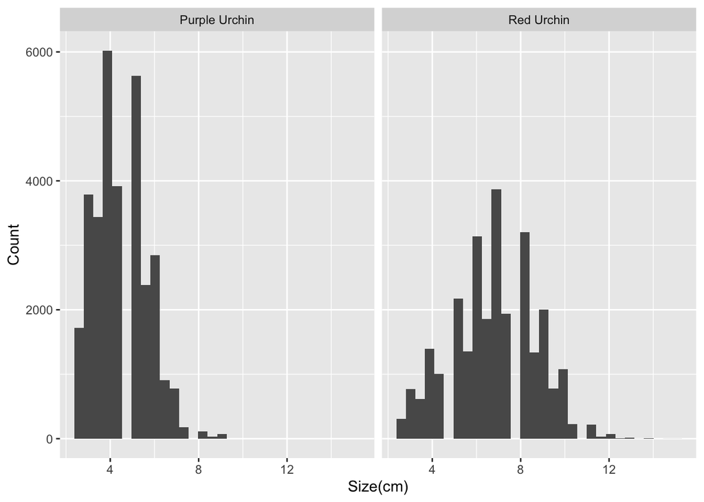

```r
urchins<- read_csv(here("data","urchins.csv"))
clean_urchins <- urchins %>% clean_names()

ggplot(data=clean_urchins,aes(x= size))+
  geom_histogram()+
  facet_wrap(~common_name)+
  labs(x= "Size(cm)", y= "Count")
```

### Boxplot

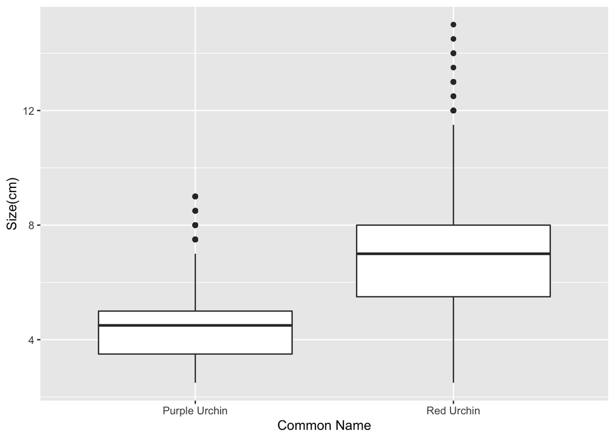

```r
ggplot(data = clean_urchins, aes(x= common_name, y= size))+
  geom_boxplot()+
  labs(x= "Common Name", y= "Size(cm)")
```

### Descriptive Statistics Table

Here we use kable_styling to better visualize the data in the final document

```r
urchin_table<- clean_urchins %>%
  group_by(common_name) %>%
  summarize(mean= mean(size), median(median(size), sd= sd(size), n= n()))
kbl(urchin_table) %>%
  kable_styling()
```

| common_name | mean | median(median(size), sd = sd(size), n = n()) |
| --- | --- | --- |
| Purple Urchin | 4.469797 | 4.5 |
| Red Urchin | 6.776489 | 7.0 |

### Overall Takeways

Looking at the various graphs above, it is fairly clear to see that the sample of the red Urchin population seems to be more normally distributed than the sample of the purple urchin population. The purple urchin sample has much less spread and is concentrated on the lower end as compared to the red urchins. When comparing the means of the two samples, the purple urchin (4.47 cm) is much lower than that of the red urchins (6.78 cm) and although these graphs do not make the mean very clear, they give a general idea of where thew values would be for both populations.

## Exploring Purple Urchins

We will show focus on the purple urchin population size by different sites and year.

```r
purple_urchins <- clean_urchins %>%
  filter(common_name== "Purple Urchin") %>%
  mutate(Date= mdy(date)) %>%
  mutate(year= year(Date)) %>%
  mutate(site_full= case_when(
    site== "NAPL" ~ "Naples Reef",
    site== "AQUE" ~ "Arroyo Quemado",
    site== "CARP" ~ "Carpinteria Reef",
    site== "MOHK" ~ "Mohawk Reef",
    site== "IVEE" ~ "Isla Vista Reef"
  ))
```

### Summary table

Summary table of the purple urchins by the amount collected, where they were collected, and in what year

```r
purchin_table <- purple_urchins %>%
  group_by(site_full, year) %>%
  count(site_full, year)
purchin_table
```

```
## # A tibble: 61 x 3
## # Groups:   site_full, year [61]
##    site_full       year     n
##    <chr>          <dbl> <int>
##  1 Arroyo Quemado  2008    67
##  2 Arroyo Quemado  2009   926
##  3 Arroyo Quemado  2010   921
##  4 Arroyo Quemado  2011   887
##  5 Arroyo Quemado  2012   764
##  6 Arroyo Quemado  2013   434
##  7 Arroyo Quemado  2014   410
##  8 Arroyo Quemado  2015   400
##  9 Arroyo Quemado  2016   342
## 10 Arroyo Quemado  2017   406
## # … with 51 more rows
```

### Exploratory Graph

This graph is to explore the purple urchins by the same catgories as the summary table above

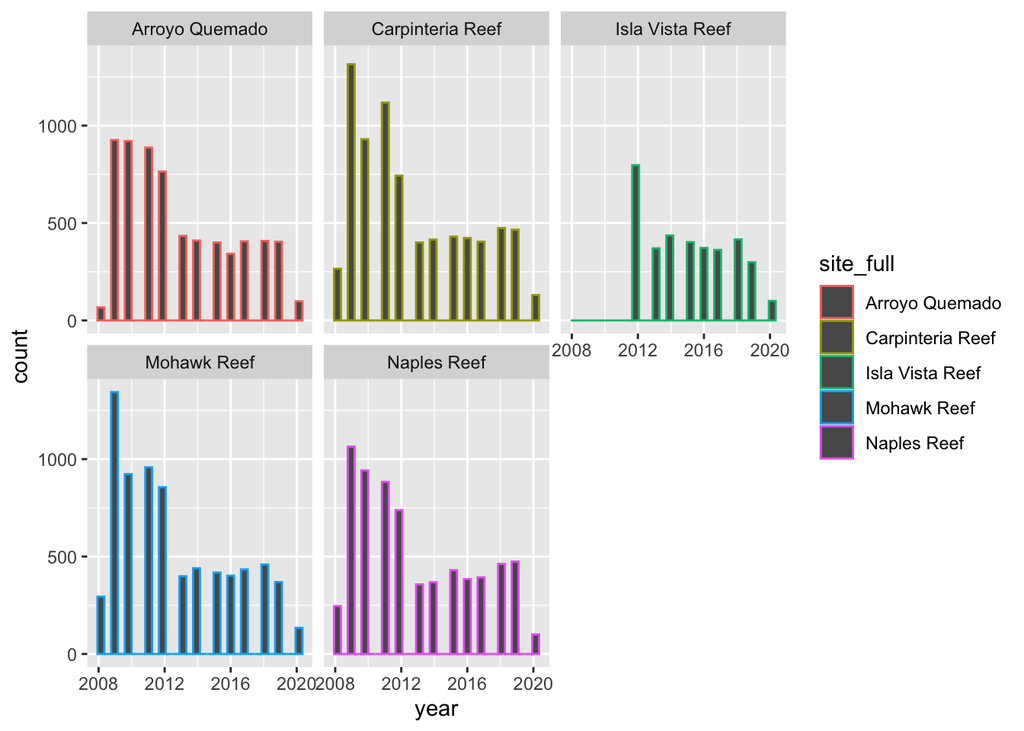

```r
ggplot(data= purple_urchins, aes(x= year, color= site_full))+
  geom_histogram(bins= 30) +
  facet_wrap(~site_full)
```

```r
purchin_table
```

```
## # A tibble: 61 x 3
## # Groups:   site_full, year [61]
##    site_full       year     n
##    <chr>          <dbl> <int>
##  1 Arroyo Quemado  2008    67
##  2 Arroyo Quemado  2009   926
##  3 Arroyo Quemado  2010   921
##  4 Arroyo Quemado  2011   887
##  5 Arroyo Quemado  2012   764
##  6 Arroyo Quemado  2013   434
##  7 Arroyo Quemado  2014   410
##  8 Arroyo Quemado  2015   400
##  9 Arroyo Quemado  2016   342
## 10 Arroyo Quemado  2017   406
## # … with 51 more rows
```